# BMI713 Problem Set 4

Ivan Sanchez Fernandez

#### Instructions:

Please submit this problem set before class on Tuesday, November 21. Problem sets may be submitted within a week past the due date at a 20% penalty; each person is allowed to submit one problem late (within a week) without penalty. Please include comments in your code to show your work and to clearly indicate your answers. Commented code tends to receive more partial credit!

If you have any questions, please post on the piazza site. This problem set was prepared by Eric Bartell and Jacob Luber, so they will be most prepared to answer questions.

## 1. Correlations (40 points)

Load in the US census population data posted on piazza under the resources tab. The first column is the year the census was taken and second column is the US population. We want to investigate how the passage of time is correlated with the US population.

```r
# Load the database and check that it looks reasonable
USPOP <- read.csv("G:\\BMI713 Computational Statistics for Biomedical Sciences\\Homework4\\USPop.csv")
dim(USPOP)
```

```
## [1] 23  2
```

```r
USPOP[1:10, ]
```

```
##    Year Population
## 1  1790    3929214
## 2  1800    5308483
## 3  1810    7239881
## 4  1820    9638453
## 5  1830   12866020
## 6  1840   17069453
## 7  1850   23191876
## 8  1860   31443321
## 9  1870   39818449
## 10 1880   50155783
```

### (a) Pearson (10 points)

Calculate the Pearson correlation coefficient. This should be coded “by hand” (use the formulation from lecture; do not use the cor() function). Report r between time and US population. The formula for the Pearson’s correlation coefficient is
$$r = \dfrac{1}{(n - 1)} \sum (\dfrac{x_i - \bar{x}}{s_x}) (\dfrac{y_i - \bar{y}}{s_y})$$

```r
# Calculate 1 / (n - 1)
initialterm <- 1 / (dim(USPOP)[1] - 1)

# Calculate the sum with a loop that goes from 1 to n
valuesum <- vector()
for (i in 1 : dim(USPOP)[1]) {
  valuefori <- ((USPOP$Year[i] - mean(USPOP$Year)) / sd(USPOP$Year)) * ((USPOP$Population[i] - mean(USPOP$Population)) / sd(USPOP$Population))
  valuesum <- c(valuesum, valuefori)
}
finalsum <- sum(valuesum)

# Calculate the Pearson correlation coefficient
r <- initialterm * finalsum
r
```

```
## [1] 0.9585941
```

```r
# The Pearson correlation coefficient between year and US population is 0.9585941

# Which is the same as from the built-in method
cor(USPOP$Year, USPOP$Population, method = "pearson")
```

```
## [1] 0.9585941
```

### (b) P-value (10 points)

Calculate p-value using both the test statistic t and Fisher’s Z-transformation, using the formulas described in class. What do these p-values tell us? The formula for the t statistic is
$$t = r \sqrt{\dfrac{n - 2}{1 - r^2}}$$

```r
# Calculate t
t <- r * sqrt((dim(USPOP)[1] - 2) / (1 - r^2))

# For a t statistic with n - 2 degrees of freedom we have
onesided <- pt(t, dim(USPOP)[1] - 2, lower.tail = FALSE)
p <- onesided * 2
p
```

```
## [1] 6.265315e-13
```

```r
# The p-value is 6.265315e-13

# Which is the same as from the built-in method
cor.test(USPOP$Year, USPOP$Population, method = "pearson")
```

```
##
##  Pearson's product-moment correlation
##
## data:  USPOP$Year and USPOP$Population
## t = 15.426, df = 21, p-value = 6.265e-13
## alternative hypothesis: true correlation is not equal to 0
## 95 percent confidence interval:
##  0.9033281 0.9825549
## sample estimates:
##       cor
## 0.9585941
```

The formula for the Fisher’s Z transformation is
$$Z_r = \dfrac{1}{2} ln\dfrac{r + 1}{1 - r}$$

```r
# Calculate Fisher's Z
Z <- (1 / 2) * log((r + 1) / (1 - r))

# For a Z statistic with standard error 1 / sqrt(n - 3) we have
onesided <- pnorm(Z, mean = 0, sd = 1 / sqrt(dim(USPOP)[1] - 3), lower.tail = FALSE)
p <- onesided * 2
p
```

```
## [1] 6.492181e-18
```

```r
# The p-value is 6.492181e-18

# Which is significant but different from the built-in method but shows that the Fisher's Z is just an approximation
cor.test(USPOP$Year, USPOP$Population, method = "pearson")
```

```
##
##  Pearson's product-moment correlation
##
## data:  USPOP$Year and USPOP$Population
## t = 15.426, df = 21, p-value = 6.265e-13
## alternative hypothesis: true correlation is not equal to 0
## 95 percent confidence interval:
##  0.9033281 0.9825549
## sample estimates:
##       cor
## 0.9585941
```

```r
# These p-values tell us that, with an alpha level of 0.05, the null hypothesis that the variables year and population are not linearly correlated can be rejected.
```

### (c) Spearman (10 points)

Calculate r using the spearman correlation (you do not need to do this by hand). Comment on the difference between correlation coefficients.

```r
# Calculate Spearman's correlation coefficient
cor.test(USPOP$Year, USPOP$Population, method = "spearman")
```

```
##
##  Spearman's rank correlation rho
##
## data:  USPOP$Year and USPOP$Population
## S = 0, p-value = 1.398e-06
## alternative hypothesis: true rho is not equal to 0
## sample estimates:
## rho
##   1
```

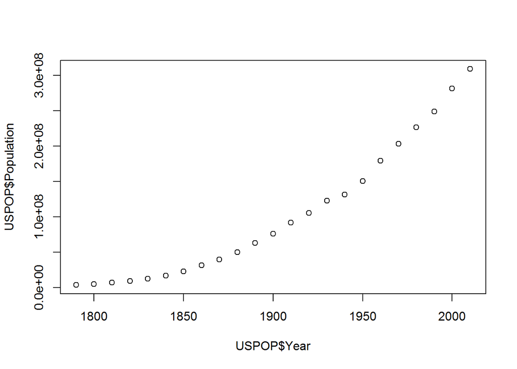

```r
# Spearman correlation coefficient gives a coefficient of 1. This is probably explained because the values do not fit an exact line and, therefore, the Pearson correlation coefficient is slightly less than 1 but the ranks of the values are exactly concordant and, therefore, the correlation of the ranks is 1
# This can be shown graphing the data
plot(USPOP$Year, USPOP$Population)
```

```r
# The data do not follow a perfect straight line, but the ranks are perfectly correlated
```

### (d) Add an outlier. (10 points)

The data from 2010 got corrupted, and the replacement value is negative the original value! Set the 2010 value to -1*(old value), and re-perform both Pearson and Spearman correlations (you may use built in functions). Comment on the different outputs.

```r
# Create the corrupted census and check that it looks as expected
corruptedCensus <- USPOP
corruptedCensus$Population[corruptedCensus$Year == 2010] <- -corruptedCensus$Population[corruptedCensus$Year == 2010]

# Calculate Pearson's correlation coefficient
cor.test(corruptedCensus$Year, corruptedCensus$Population, method = "pearson")
```

```
##
##  Pearson's product-moment correlation
##
## data:  corruptedCensus$Year and corruptedCensus$Population
## t = 1.9402, df = 21, p-value = 0.0659
## alternative hypothesis: true correlation is not equal to 0
## 95 percent confidence interval:
##  -0.02659553  0.69102806
## sample estimates:
##       cor
## 0.3898808
```

```r
# Calculate Spearman's correlation coefficient
cor.test(corruptedCensus$Year, corruptedCensus$Population, method = "spearman")
```

```
##
##  Spearman's rank correlation rho
##
## data:  corruptedCensus$Year and corruptedCensus$Population
## S = 506, p-value = 5.89e-05
## alternative hypothesis: true rho is not equal to 0
## sample estimates:
##  rho
## 0.75
```

```r
# The value for Pearson's correlation coefficient changes dramatically (from the original 0.9585941 to the current 0.3898808) while the Spearman's correlation coefficient changes much less (from the original 1 to the current 0.75). This shows that Spearman's correlation coefficient based on ranks is less susceptible to outliers than Pearson's correlation coefficient based on actual values
```

## 2. Basic Linear Regression (60 points)

We will perform linear regression on the heights of father-son pairs. Use the following code to load the dataset. The first column is fheight for father’s height, and the second column is sheight for son’s height.

```r
# Load the database and check that it looks as expected
# install.packages("UsingR")
library(UsingR)
data(father.son)
father.son[1:10, ]
```

```
##     fheight  sheight
## 1  65.04851 59.77827
## 2  63.25094 63.21404
## 3  64.95532 63.34242
## 4  65.75250 62.79238
## 5  61.13723 64.28113
## 6  63.02254 64.24221
## 7  65.37053 64.08231
## 8  64.72398 63.99574
## 9  66.06509 64.61338
## 10 66.96738 63.97944
```

### (a) Plot the data (5 points)

On a scatterplot, plot father height vs son height. Does the data appear to be roughly linearly correlated?

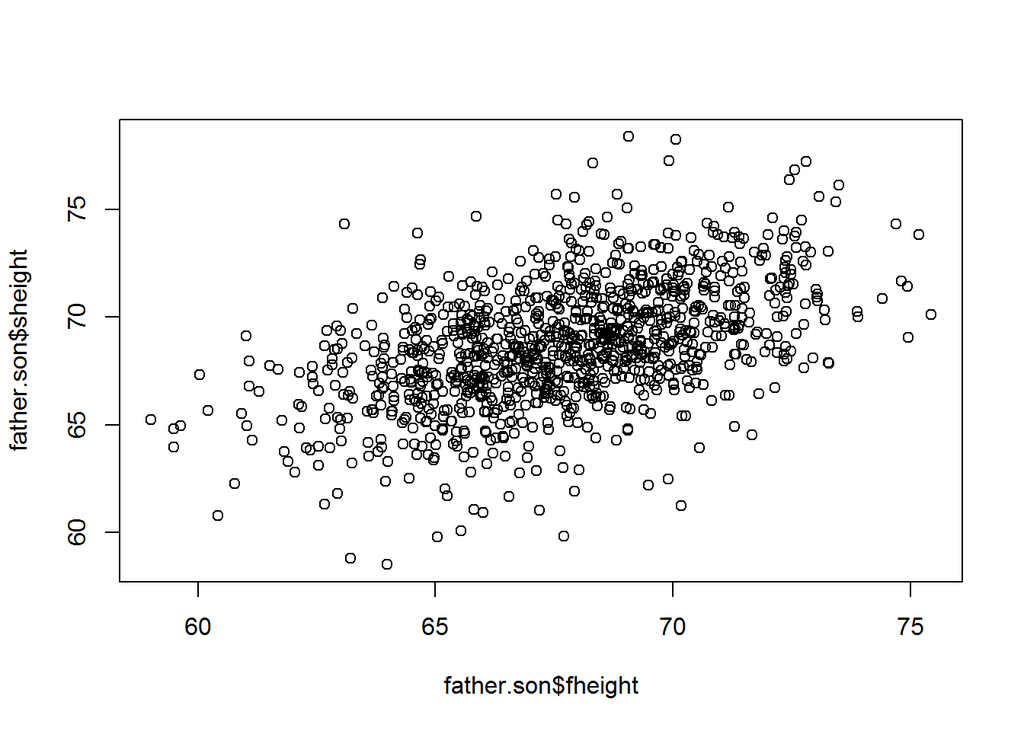

```r
# Plot the data with father height in the X axis and son height in the Y axis
plot(father.son$fheight, father.son$sheight)
```

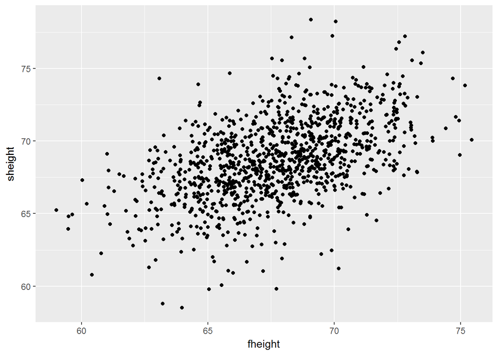

```r
# Or with ggplot2
# install.packages("ggplot2")
library(ggplot2)
ggplot(data= father.son, aes(x = fheight, y = sheight)) + geom_point()
```

```r
# The data appear to be roughly linearly correlated
```

### (b) Least squares (10 points)

Calculate the least squares line with father height as the independent variable manually. Comment your code. You do not need to perform any calculus; only calculate the slope and intercept. The formula for the least squares line slope is
$$b = \dfrac{\sum (x_i - \bar{x}) (y_i - \bar{y})}{\sum (x_i - \bar{x})^2}$$

```r
# Calculate the least squares line slope
vectorofvaluesnumerator <- vector()
vectorofvaluesdenominator <- vector()
for (i in 1 : dim(father.son)[1]) {

  valueforinumerator <- (father.son$fheight[i] - mean(father.son$fheight)) * (father.son$sheight[i] - mean(father.son$sheight))

  valueforidenominator <-(father.son$fheight[i] - mean(father.son$fheight)) ^ 2

  vectorofvaluesnumerator <- c(vectorofvaluesnumerator, valueforinumerator)

  vectorofvaluesdenominator <- c(vectorofvaluesdenominator, valueforidenominator)
}
b <- sum(vectorofvaluesnumerator) / sum(vectorofvaluesdenominator)
b
```

```
## [1] 0.514093
```

The formula for calculating the least squares line intercept is
$$a = \bar{y} - b\bar{x}$$

```r
# Calculate the least squares line intercept
a <- mean(father.son$sheight) - (b * mean(father.son$fheight))
a
```

```
## [1] 33.8866
```

```r
# Therefore, the linear equation would be
# sonheight = a + b * fatherheight
# sonheight = 33.8866 + 0.514093 * fatherheight
```

### (c) Built in (5 points)

Calculate the least squares line using the built in function, and verify that your answer to part (b) is correct.

```r
# Linear model
lsrl <- lm(sheight ~ fheight, data = father.son)
lsrl
```

```
##
## Call:
## lm(formula = sheight ~ fheight, data = father.son)
##
## Coefficients:
## (Intercept)      fheight
##     33.8866       0.5141
```

```r
summary(lsrl)
```

```
##
## Call:
## lm(formula = sheight ~ fheight, data = father.son)
##
## Residuals:
##     Min      1Q  Median      3Q     Max
## -8.8772 -1.5144 -0.0079  1.6285  8.9685
##
## Coefficients:
##             Estimate Std. Error t value Pr(>|t|)
## (Intercept) 33.88660    1.83235   18.49   <2e-16 ***
## fheight      0.51409    0.02705   19.01   <2e-16 ***
## ---
## Signif. codes:  0 '***' 0.001 '**' 0.01 '*' 0.05 '.' 0.1 ' ' 1
##
## Residual standard error: 2.437 on 1076 degrees of freedom
## Multiple R-squared:  0.2513, Adjusted R-squared:  0.2506
## F-statistic: 361.2 on 1 and 1076 DF,  p-value: < 2.2e-16
```

```r
# The answer to part b) is correct
```

### (d) Plot 2 (5 points)

Add your least squares line to your scatterplot in part (a).

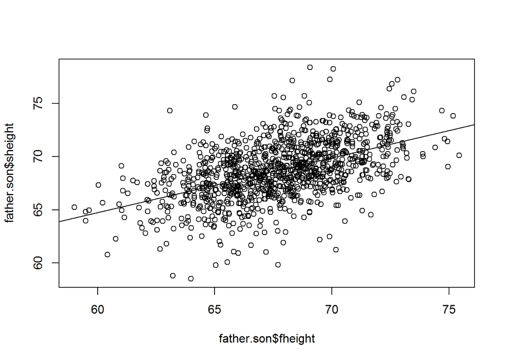

```r
# Plot the data with father height in the X axis and son height in the Y axis and the linear regression line
plot(father.son$fheight, father.son$sheight)
abline(lsrl$coefficients[1], lsrl$coefficients[2])
```

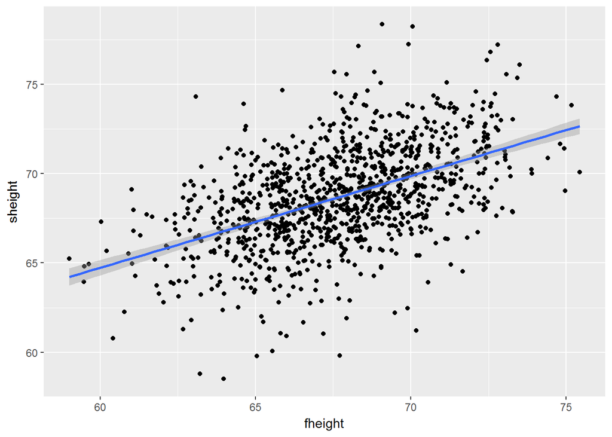

```r
# Or with ggplot2
ggplot(data= father.son, aes(x = fheight, y = sheight)) + geom_point() + geom_smooth(method = "lm", formula = y ~ x)
```

### (e) R^2 (5 points)

How well does your line fit the data? Calculate r^2 (manually). The formula for calculating the R square is
$$R^2 = \dfrac{\sum(\hat{y_i} - \bar{y})^2} {\sum(y_i - \bar{y})^2}$$

```r
# Calculate R squared
numerator <- vector()
denominator <- vector()

for (i in 1 : dim(father.son)[1]) {

  numeratorfori <- (predict(lsrl, newdata = father.son)[i] - mean(father.son$sheight)) ^ 2

  denominatorfori <- (father.son$sheight[i] - mean(father.son$sheight)) ^ 2

  numerator <- c(numerator, numeratorfori)

  denominator <- c(denominator, denominatorfori)
}

R2 <- sum(numerator) / sum(denominator)

R2
```

```
## [1] 0.2513401
```

```r
# R squared is 0.2513401

# Which is the same as the R squared calculated with the built-in method
summary(lsrl)
```

```
##
## Call:
## lm(formula = sheight ~ fheight, data = father.son)
##
## Residuals:
##     Min      1Q  Median      3Q     Max
## -8.8772 -1.5144 -0.0079  1.6285  8.9685
##
## Coefficients:
##             Estimate Std. Error t value Pr(>|t|)
## (Intercept) 33.88660    1.83235   18.49   <2e-16 ***
## fheight      0.51409    0.02705   19.01   <2e-16 ***
## ---
## Signif. codes:  0 '***' 0.001 '**' 0.01 '*' 0.05 '.' 0.1 ' ' 1
##
## Residual standard error: 2.437 on 1076 degrees of freedom
## Multiple R-squared:  0.2513, Adjusted R-squared:  0.2506
## F-statistic: 361.2 on 1 and 1076 DF,  p-value: < 2.2e-16
```

### (f) Residuals (5 points)

Plot the residuals for different values of x, and comment on their distribution.

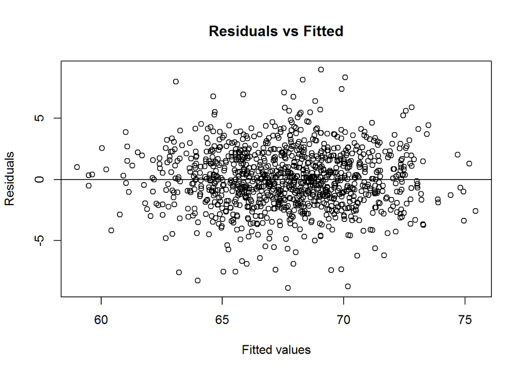

```r
# Plot the residuals
plot(father.son$fheight, resid(lsrl),
     ylab= "Residuals", xlab = "Fitted values",
     main= "Residuals vs Fitted")
abline(0, 0)
```

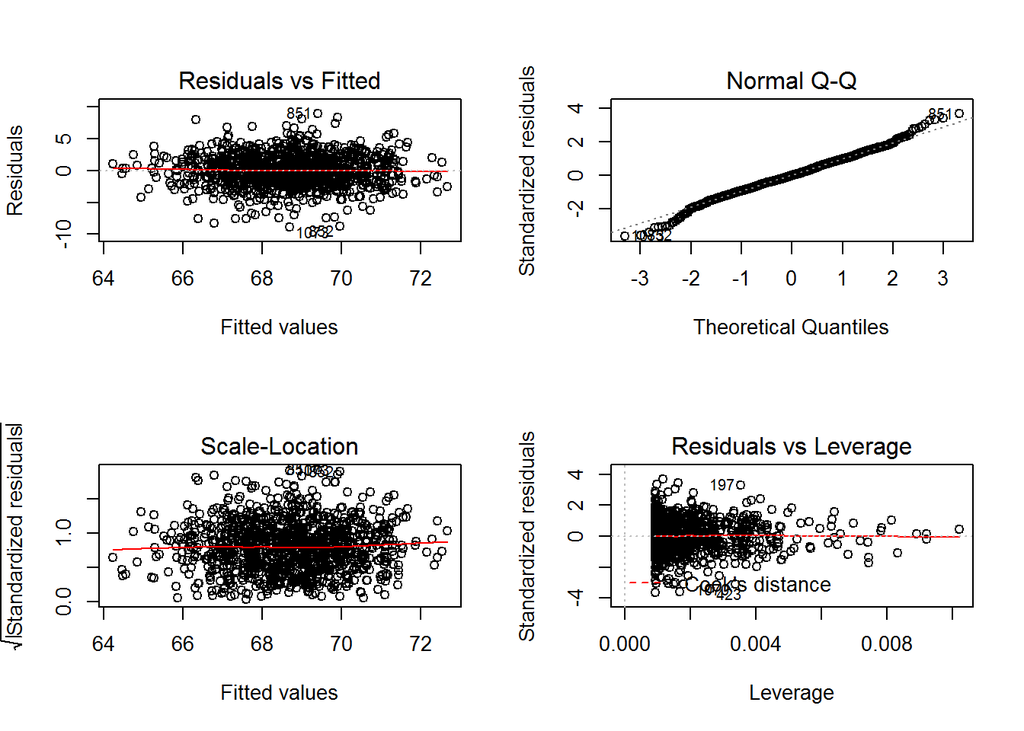

```r
# The distribution of the residuals follows a distribution with mean 0 and approximately equal variance. The narrower variance at the extreme values of x is explained just because there are fewer values and tend to fall within the central parts of the distribution. In summary, the residuals show that there are no major departures from the homoscedaticity assumption

# A more complete evaluation includes plots for residuals vs fitted, normal quantile-quantile, scale-location, and residuals vs leverage
par(mfrow = c(2, 2))
plot(lsrl)
```

```r
# These plots also suggest no major departures from the linear model assumptions. The residuals vs leverage plot shows that the points with more leverage (in the extreme of the x variable) have residuals with minor departures from 0 (no major outliers)
```

### (g) Significance (10 points)

How significant is our slope? Calculate both the t-stat and the p-value, and comment on the correlation’s significance. The formula for calculating the standard error of b is
$$se(b) = \sqrt{\dfrac {(1 / (n - 2)) \sum(y_i - \hat{y_i})^2} {\sum(x_i - \hat{x_i})^2}}$$

```r
# Calculate se(b)
firstpartofnumerator <- 1 / (dim(father.son)[1] - 2)

numerator <- vector()
denominator <- vector()

for (i in 1 : dim(father.son)[1]) {

  numeratorfori <- (father.son$sheight[i] - predict(lsrl, newdata = father.son)[i]) ^ 2

  denominatorfori <- (father.son$fheight[i] - mean(father.son$fheight)) ^ 2

  numerator <- c(numerator, numeratorfori)

  denominator <- c(denominator, denominatorfori)
}


SEb <- sqrt((firstpartofnumerator * sum(numerator)) / sum(denominator))
SEb
```

```
## [1] 0.02704874
```

The formula for calculating the t statistic is
$$t = \dfrac{b} {se(b)}$$

```r
# Calculate t
t <- b / (SEb)
t
```

```
## [1] 19.00618
```

```r
# For a t distribution with n - 2 degrees of freedom it is
onesided <- pt(t, df = dim(father.son)[1] - 2, lower.tail = FALSE)
p <- onesided * 2
p
```

```
## [1] 1.121268e-69
```

```r
# The p-value is 1.121268e-69

# Which is the same as 1.121268e-69
summary(lsrl)$coefficients
```

```
##              Estimate Std. Error  t value     Pr(>|t|)
## (Intercept) 33.886604 1.83235382 18.49348 1.604044e-66
## fheight      0.514093 0.02704874 19.00618 1.121268e-69
```

```r
# Based on these p-values it can be concluded that the null hypothesis that the son height is not associated with the father height can be rejected with an alpha level of 0.05
```